# Kviz 3

Avtor

Miha Prajs

## Priprava podatkov

**Koda**

```r
library(tidyverse)

my.data <- read.table("C:/Users/mihap/Code/Faks/famnit24-statistika/HW/Kvizi/Kviz3/data.txt",
                      header=TRUE,
                      stringsAsFactors=TRUE, sep="",
                      na.strings="NA",
                      dec=".",
                      strip.white=TRUE)
x <- 4
z <- 6
my.data <- my.data[unique(c(seq(x,
                                nrow(my.data)
                                ,by=10),
                            seq(z,
                                nrow(my.data)
                                ,by=10))),]
```

## 1. naloga

**H0:** Povprečna številka čevlja je enaka za moške in ženske.

**H1:** Povprečna številka čevlja se razlikuje med moškimi in ženskami.

**Koda**

```r
t.test(my.data$Shoe.size~my.data$Sex,var.equal=T,conf.level=0.99)
```

```
    Two Sample t-test

data:  my.data$Shoe.size by my.data$Sex
t = -13.975, df = 103, p-value < 2.2e-16
alternative hypothesis: true difference in means between group female and group male is not equal to 0
99 percent confidence interval:
 -5.069337 -3.466434
sample estimates:
mean in group female   mean in group male
            39.02941             43.29730
```

**Statistični sklep:** Številka čevlja študentk se statistčno značilno razlikuje od številke čevlja študentov.

## 2. naloga

Na spodnjem grafu so predstavljeni podatki o številki čevlja v odvisnosti od teže.

**Koda**

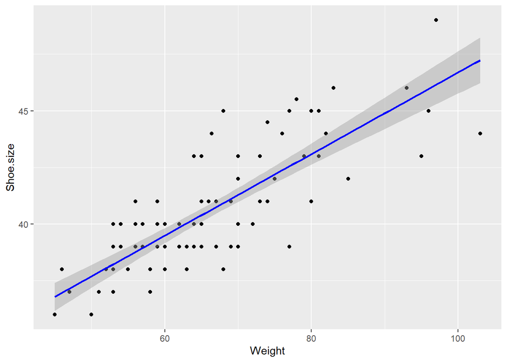

```r
ggplot(my.data,aes(x=Weight,y=Shoe.size)) +
  geom_point() +
  geom_smooth(method="lm",col="blue")
```

Iz grafa lahko opazimo, da sta teža in številka čevlja med seboj povezani. To nam zelo dobro prikaže modra trendna črta.

**Koda**

```r
summary(lm(Shoe.size~Weight,data=my.data))
```

```
Call:
lm(formula = Shoe.size ~ Weight, data = my.data)

Residuals:
    Min      1Q  Median      3Q     Max
-3.5502 -1.0304 -0.1103  1.0294  4.0697

Coefficients:
            Estimate Std. Error t value Pr(>|t|)
(Intercept) 28.69129    0.87095   32.94   <2e-16 ***
Weight       0.17999    0.01305   13.79   <2e-16 ***
---
Signif. codes:  0 '***' 0.001 '**' 0.01 '*' 0.05 '.' 0.1 ' ' 1

Residual standard error: 1.508 on 103 degrees of freedom
Multiple R-squared:  0.6488,    Adjusted R-squared:  0.6454
F-statistic: 190.3 on 1 and 103 DF,  p-value: < 2.2e-16
```

Funkcija lm nam prikaže še s številkami pove, da sta spremenljivki povezani, saj je stopnja značilnosti manjša od 0,001.

## 3. naloga

**H0:** Teža in ure športa na teden nista monotono povezani.

**H1:** Teža in ure športa na teden sta monotono povezani.

**Koda**

```r
cor.test(my.data$Weight,my.data$Sport..hours.per.week.,method="spearman")
```

```
    Spearman's rank correlation rho

data:  my.data$Weight and my.data$Sport..hours.per.week.
S = 163837, p-value = 0.1248
alternative hypothesis: true rho is not equal to 0
sample estimates:
      rho
0.1507495
```

Ker je *p*-vrednost večja od 0,05, podatki ne kažejo statistično značilne monotone povezanosti.

## 4. naloga

**H0:** Zastopanost domačih ljubljenčkov ustreza dani porazdelitvi.

**H1:** Zastopanost domačih ljubljenčkov se razlikuje od dane porazdelitve.

**Koda**

```r
pets <- c("PetCat","PetDog","PetFish","PetOther")
observed <- colSums(my.data[pets]=="Yes")
expected <- c(0.41,0.33,0.10,0.16)*sum(observed)

chisq.test(observed,p=expected,rescale.p=T)
```

```
    Chi-squared test for given probabilities

data:  observed
X-squared = 1.9017, df = 3, p-value = 0.5931
```

Ker je *p*-vrednost večja od α, ne moremo zavrniti ničelne hipoteze. Domačih ljubljenčkov v populciji študentov torej ustreza podani porazdelitvi.